# Residual Model

Jay, Alec, Lynn

5/21/2021

```r
library(tidyverse)
library(nlme)
library(mgcv)
aids = read.csv("aids.csv")


aids = aids %>%
  mutate(occasion = ceiling(week),
         gender = factor(gender, level = c("male", "female")),
         treatment = as.factor(treatment))

glimpse(aids)
```

```
## Rows: 5,036
## Columns: 7
## $ id        <int> 1, 1, 1, 1, 1, 1, 2, 2, 2, 2, 2, 2, 3, 4, 4, 4, 4, 5, 5, 5,…
## $ treatment <fct> 2, 2, 2, 2, 2, 2, 4, 4, 4, 4, 4, 4, 1, 3, 3, 3, 3, 1, 1, 1,…
## $ age       <dbl> 36.4271, 36.4271, 36.4271, 36.4271, 36.4271, 36.4271, 47.84…
## $ gender    <fct> male, male, male, male, male, male, male, male, male, male,…
## $ week      <dbl> 0.0000, 7.5714, 15.5714, 23.5714, 32.5714, 40.0000, 0.0000,…
## $ log_cd4   <dbl> 3.135494, 3.044522, 2.772589, 2.833213, 3.218876, 3.044522,…
## $ occasion  <dbl> 0, 8, 16, 24, 33, 40, 0, 8, 16, 23, 31, 39, 0, 0, 8, 17, 33…
```

# Current Model

```r
aids <- aids %>%
    mutate(knot_term1 = if_else((treatment == 4 & occasion <= 16), occasion^2, 0)) %>%
    relocate(knot_term1, .after = occasion)


ctrl <- lmeControl(opt = 'optim')
model_spline2 = lme(log_cd4 ~ occasion +
             treatment:occasion + age + knot_term1,
             data = aids,
             random = ~ occasion | id,
             method = "REML",
             control = ctrl)


summary(model_spline2)
```

```
## Linear mixed-effects model fit by REML
##   Data: aids
##        AIC      BIC    logLik
##   12086.38 12158.14 -6032.192
##
## Random effects:
##  Formula: ~occasion | id
##  Structure: General positive-definite, Log-Cholesky parametrization
##             StdDev     Corr
## (Intercept) 0.80105770 (Intr)
## occasion    0.01572499 0.187
## Residual    0.57838872
##
## Fixed effects:  log_cd4 ~ occasion + treatment:occasion + age + knot_term1
##                          Value  Std.Error   DF   t-value p-value
## (Intercept)          2.5910590 0.11844924 3722 21.874846  0.0000
## occasion            -0.0166243 0.00169301 3722 -9.819372  0.0000
## age                  0.0103633 0.00306361 1307  3.382714  0.0007
## knot_term1           0.0014324 0.00022957 3722  6.239584  0.0000
## occasion:treatment2  0.0024427 0.00237231 3722  1.029676  0.3032
## occasion:treatment3  0.0066011 0.00236783 3722  2.787822  0.0053
## occasion:treatment4  0.0163926 0.00234301 3722  6.996385  0.0000
##  Correlation:
##                     (Intr) occasn age    knt_t1 occs:2 occs:3
## occasion            -0.030
## age                 -0.976  0.004
## knot_term1          -0.023  0.012  0.001
## occasion:treatment2  0.002 -0.704 -0.001  0.000
## occasion:treatment3  0.003 -0.705 -0.003  0.000  0.503
## occasion:treatment4  0.005 -0.713 -0.005  0.021  0.508  0.509
##
## Standardized Within-Group Residuals:
##         Min          Q1         Med          Q3         Max
## -4.21391522 -0.43707165  0.03003612  0.48390366  3.64340496
##
## Number of Observations: 5036
## Number of Groups: 1309
```

```r
model_quadratic = lme(log_cd4 ~ occasion + I(occasion^2) +
             treatment:occasion + treatment:I(occasion^2)
               +  age, data = aids,
             random = ~ occasion + I(occasion^2)| id,
             method = "REML")

summary(model_quadratic)
```

```
## Linear mixed-effects model fit by REML
##   Data: aids
##        AIC      BIC    logLik
##   12012.15 12123.03 -5989.074
##
## Random effects:
##  Formula: ~occasion + I(occasion^2) | id
##  Structure: General positive-definite, Log-Cholesky parametrization
##               StdDev       Corr
## (Intercept)   0.7599938521 (Intr) occasn
## occasion      0.0419502978  0.324
## I(occasion^2) 0.0009560662 -0.388 -0.921
## Residual      0.5471601520
##
## Fixed effects:  log_cd4 ~ occasion + I(occasion^2) + treatment:occasion + treatment:I(occasion^2) +      age
##                               Value  Std.Error   DF   t-value p-value
## (Intercept)               2.5752869 0.11577884 3719 22.243157  0.0000
## occasion                 -0.0121774 0.00490731 3719 -2.481477  0.0131
## I(occasion^2)            -0.0001246 0.00013405 3719 -0.929607  0.3526
## age                       0.0096541 0.00299309 1307  3.225454  0.0013
## occasion:treatment2       0.0073306 0.00687138 3719  1.066826  0.2861
## occasion:treatment3       0.0186714 0.00686433 3719  2.720053  0.0066
## occasion:treatment4       0.0438518 0.00679921 3719  6.449549  0.0000
## I(occasion^2):treatment2 -0.0001429 0.00018701 3719 -0.764175  0.4448
## I(occasion^2):treatment3 -0.0003638 0.00018841 3719 -1.931005  0.0536
## I(occasion^2):treatment4 -0.0008388 0.00018542 3719 -4.523868  0.0000
##  Correlation:
##                          (Intr) occasn I(c^2) age    occs:2 occs:3 occs:4
## occasion                 -0.026
## I(occasion^2)             0.016 -0.939
## age                      -0.975  0.003 -0.002
## occasion:treatment2       0.002 -0.707  0.666 -0.001
## occasion:treatment3       0.002 -0.707  0.667 -0.002  0.505
## occasion:treatment4       0.002 -0.714  0.673 -0.001  0.510  0.510
## I(occasion^2):treatment2 -0.002  0.669 -0.714  0.001 -0.939 -0.478 -0.482
## I(occasion^2):treatment3 -0.002  0.663 -0.709  0.002 -0.474 -0.939 -0.479
## I(occasion^2):treatment4  0.000  0.674 -0.720 -0.001 -0.481 -0.482 -0.939
##                          I(^2):2 I(^2):3
## occasion
## I(occasion^2)
## age
## occasion:treatment2
## occasion:treatment3
## occasion:treatment4
## I(occasion^2):treatment2
## I(occasion^2):treatment3  0.508
## I(occasion^2):treatment4  0.516   0.512
##
## Standardized Within-Group Residuals:
##         Min          Q1         Med          Q3         Max
## -4.48485816 -0.41732683  0.02411476  0.46989002  3.88629654
##
## Number of Observations: 5036
## Number of Groups: 1309
```

```r
#Anova on our two models above
anova(model_spline2, model_quadratic)
```

```
##                 Model df      AIC      BIC    logLik   Test  L.Ratio p-value
## model_spline2       1 11 12086.38 12158.14 -6032.192
## model_quadratic     2 17 12012.15 12123.03 -5989.074 1 vs 2 86.23638  <.0001
```

An ANOVA analysis on our two models above demonstrates that the quadratic model seems to be a better fit for the data that we are given. A significant p-value (p < 0.001) further verifies this assertion.

# Residual Analysis

## Histogram of Transformed and Non-transformed Residuals

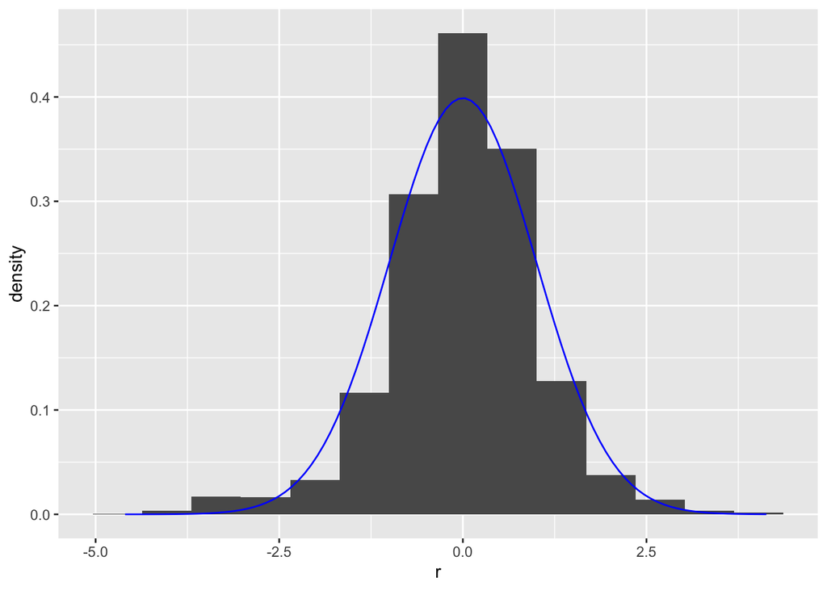

```r
res_prog = residuals(model_quadratic, level = 0)


sigma_i = extract.lme.cov(model_quadratic, aids)

#lower triangular matrix
L_i = t(chol(sigma_i))

#transformed residuals
res_prog_trans = solve(L_i) %*% res_prog


tibble(r = res_prog_trans) %>%
  ggplot(aes(x = r)) +
  geom_histogram(aes(y = stat(density)), bins = 14 ) +
  geom_function(fun = dnorm, color = "blue")
```

This plot shows the density of our transformed residuals. It appears that our transformed residuals seem to follow a Normal distribution, or at the very least, a a symmetric distribution.

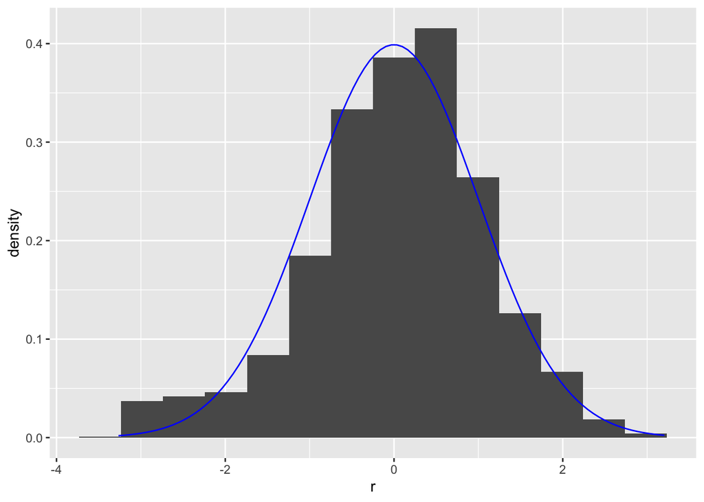

```r
tibble(r = res_prog) %>%
  ggplot(aes(x = r)) +
  geom_histogram(aes(y = stat(density)), bins = 14 ) +
  geom_function(fun = dnorm, color = "blue")
```

This plot shows the distribution of our residuals (without any transformation). The distribution appears to be a little more left-skewed in comparison to the histogram of our transformed residuals.

## QQ-Plot

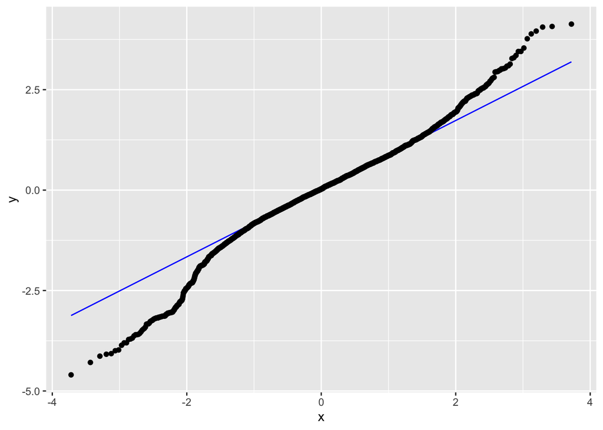

```r
tibble(r = res_prog_trans) %>%
  ggplot(aes(sample = r)) +
  geom_qq_line(color = "blue") +
  geom_qq()
```

## Transformed Predicted values vs. Transformed Residuals

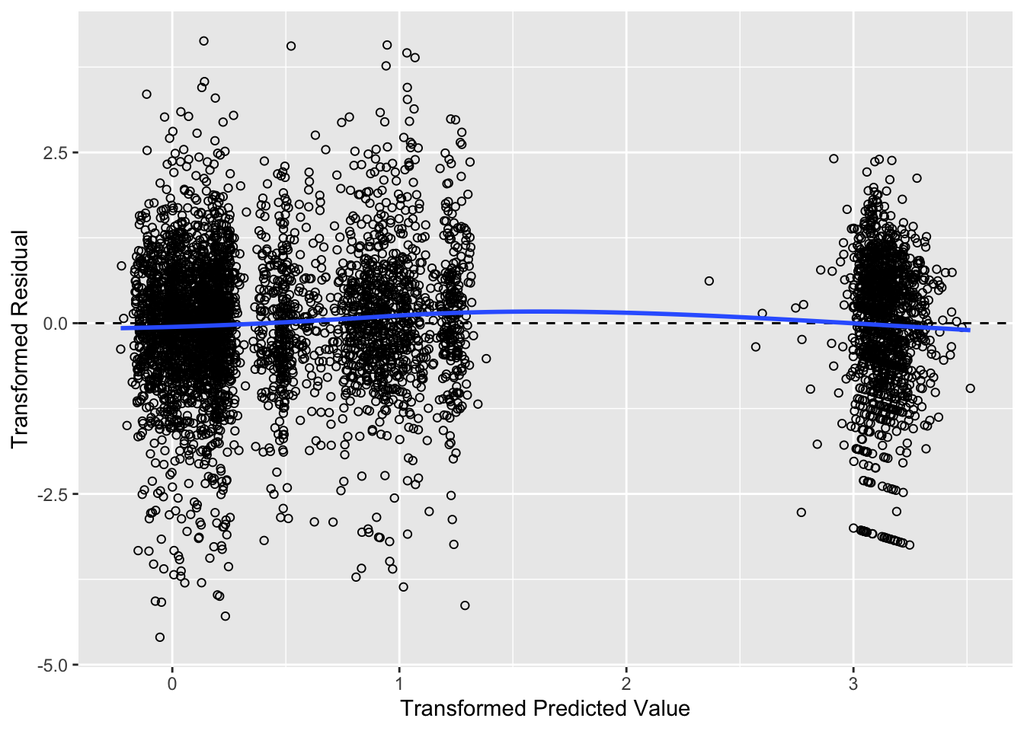

```r
#transformed vs actual residual
mu_hat = fitted(model_quadratic, level = 0)
mu_hat_transformed = solve(L_i) %*% mu_hat


tibble(x = mu_hat_transformed, y = res_prog_trans) %>%
  ggplot(aes(x = x, y = y)) +
  geom_hline(yintercept = 0, linetype = "dashed") +
  geom_point(shape = 1) +
  geom_smooth(method = "loess", se = FALSE) +
  labs(x = "Transformed Predicted Value", y = "Transformed Residual")
```

We can see that there doesn’t seem to be any significant curvature in this graph, indicating that the constant variance assumption is correct.  
However, we can see that there is a large gap between the points, which shows that there seems to be a gap in observed the covariates (x values).